# Exploring the BRFSS data

## Setup

### Load packages

```r
library(ggplot2)
library(dplyr)
```

### Load data

Make sure your data and R Markdown files are in the same directory. When loaded your data file will be called `brfss2013`. Delete this note when before you submit your work.

```r
load("brfss2013.RData")
```

## Part 1: Data

Generalizability：

BRFFS data is collected by disproportionate sampling method; it’s a stratified sampling and the size of sampling doesn’t have to equal population size. The strati are defined and conducted by CDC and states. To process a national range research across different states is difficult due to the large number of targets and geographical restriction. On the other hand, the telephone survey is a fast, simple, effective way to collect data without geographical restriction.

However, there are some problems with telephone survey that we cannot ignore, such as short interviewing time, limited access to contact targets, interruption of interview, easy rejection of the interview; this data cannot support those missing parts. Nevertheless, those flaws cannot belittle virtues; using telephone survey is much more economic and efficiency in this case rather than other methods.

Causality：

In this research, there are many variables look strong connected; however, it’s difficult to classify variables of causes or result. Therefore, we can only find association, not causality.

## Part 2: Research questions

**Research quesion 1:** Does sleeping time associate with the ratio of heart attack?

*Dependent Variable:

sleptim1: How Much Time Do You Sleep

*Associated Variables:

cvdinfr4: Ever Diagnosed With Heart Attack

Sleeping time is critical to measure the physical health and heart attack is one of deadly physical disease; does sleeping time and heart attack have any association would be an important information.In this case, I am going to focus on heart attacked and non-heart-attacked people’s sleeping time and looking for any associations.

**Research quesion 2:** The association of income between physical and mental health.

*Dependent Variable:

income2: Income Level

*Associated Variables：

physhlth: Number Of Days Physical Health Not Good

menthlth: Number Of Days Mental Health Not Good

Diverse incomes might represent levels of affordability on medical service which impact physical health directly; but does different incomes could associate with mental health as physical health? In this question, I am going to compare those people who are physically and mentally not good in days and try to find the association with income.

**Research quesion 3:** Does smoking helps on controlling the weight?

*Dependent Variable:

smokday2: Frequency Of Days Now Smoking

stopsmk2: Stopped Smoking In Past 12 Months

*Associated Variables:

_rfbmi5: Overweight Or Obese Calculated Variable

Overweight, obese are common modern ills nowadays; study BMI differences between smoking and non-smoking people is an attracting topic to support on controlling the weight. In this question, I am going to study the number of overweight or obese people distribution in various smoking habits.

## Part 3: Exploratory data analysis

**Research quesion 1:**

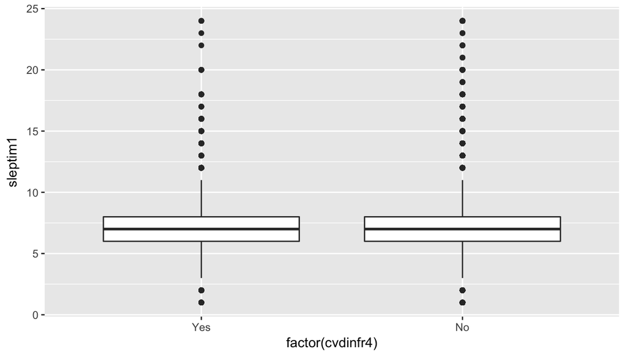

```r
heart_attack <- brfss2013 %>% filter(sleptim1 <= 24, cvdinfr4 != "")       # select sleeping time between "1-24"" hrs and heart attack response doesn't equal to "NA"", then save it to “heart_attack”

ggplot(data = heart_attack, aes(x = factor(cvdinfr4), y = sleptim1)) + geom_boxplot() #visualize the distribution of sleeping time between heart attacked and non-heart attacked people.
```

```r
# The distribution of both sides shows very similar result of 6-8 sleeping hours; there are no significant association between sleeping time and heart attack in this case.
```

**Research quesion 2:**

```r
menthlth_income <- brfss2013 %>% filter(income2 != " ", menthlth <= 30)           # Filter the income that doesn’t equal to "NA"" and Mental Health Not Good day number smaller than 30; then save it to menthlth_income.

physhlth_income <- brfss2013 %>% filter(income2 != " ", physhlth <= 30)         # Filter the income that doesn’t equal to "NA"" and Physical Health Not Good day number smaller than 30; then save it to physhlth_income.

physhlth_income %>% group_by(income2) %>% summarise(mean_phy = mean(physhlth)) %>% arrange((desc(mean_phy)))        #compute the mean of Physical Health Not Good day in different income range. The computation indicates that the mean of physical unwell days of people whose income are more than $75,000 is about 2.08, which is much more lower than people who earn less than $10,000(unwell day mean 9.37).
```

```
## # A tibble: 8 × 2
##             income2 mean_phy
##              <fctr>    <dbl>
## 1 Less than $10,000 9.371926
## 2 Less than $15,000 8.898666
## 3 Less than $20,000 6.780926
## 4 Less than $25,000 5.555594
## 5 Less than $35,000 4.503282
## 6 Less than $50,000 3.591186
## 7 Less than $75,000 2.895871
## 8   $75,000 or more 2.089032
```

```r
menthlth_income %>% group_by(income2) %>% summarise(mean_men = mean(menthlth)) %>% arrange((desc(mean_men)))        #Compute the mean of "Mental Health Not Good day" in different income range. The computation indicates that the mean of mental unwell days of people whose income are more than $75,000 is about 1.93, which is much more lower than people who earn less than $10,000(unwell day mean 7.82).
```

```
## # A tibble: 8 × 2
##             income2 mean_men
##              <fctr>    <dbl>
## 1 Less than $10,000 7.820302
## 2 Less than $15,000 6.336172
## 3 Less than $20,000 4.912541
## 4 Less than $25,000 4.232141
## 5 Less than $35,000 3.352378
## 6 Less than $50,000 2.861721
## 7 Less than $75,000 2.481523
## 8   $75,000 or more 1.932057
```

```r
9.37/2.08 # Compare the mean of physical unwell day between highest income and lowest income
```

```
## [1] 4.504808
```

```r
7.82/1.93 #Compare the mean of mental unwell day between highest income and lowest income
```

```
## [1] 4.051813
```

```r
# The mean result indicates that income does associate with physical and mental health; however, the impact on physical is slightly more than mental.
```

**Research quesion 3:**

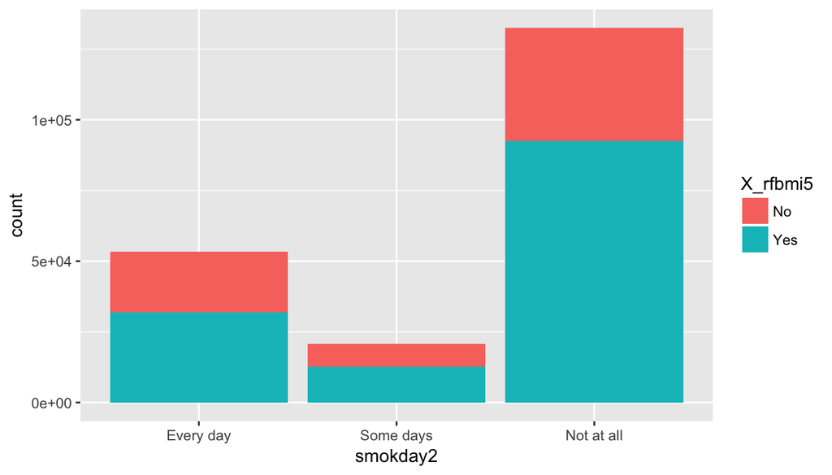

```r
smokday2_filter <- brfss2013 %>% filter(smokday2 != "", X_rfbmi5 != "")     # Filter the frequency of smoking day and Overweight Or Obese BMI that don’t equal to "NA""; save it to smokday2_filter.

ggplot(smokday2_filter, aes(x = smokday2, fill = X_rfbmi5)) + geom_bar()        #Visualize the Overweight Or Obese BMI between different frequency of smoking day.
```

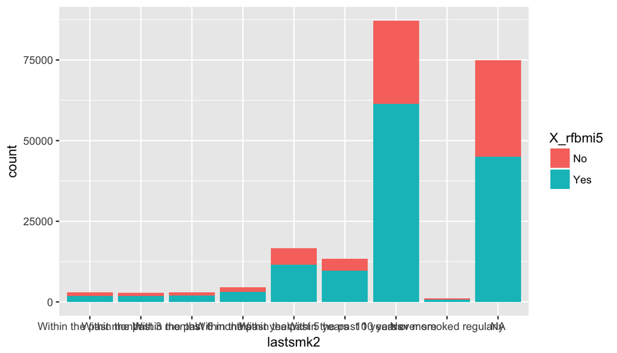

```r
ggplot(smokday2_filter, aes(x = lastsmk2, fill = X_rfbmi5)) + geom_bar()        #Visualize the Overweight Or Obese BMI between different time of last smoked cigarette.
```

```r
smokday2_filter %>% group_by(smokday2) %>% summarise(bmi_rate = sum(X_rfbmi5 == "Yes")/n())     # Compute overweight Or obese BMI rate in different frequency of smoking day. The obese BMI rate of everyday smoker is 0.59, about 0.1 lower than non-smoker, 0.69;still, the ratio of smoking someday and everyday are no obvious different.
```

```
## # A tibble: 3 × 2
##     smokday2  bmi_rate
##       <fctr>     <dbl>
## 1  Every day 0.5992324
## 2  Some days 0.6058454
## 3 Not at all 0.6978070
```

```r
smokday2_filter %>% group_by(lastsmk2) %>% summarise(bmi_rate = sum(X_rfbmi5 == "Yes")/n())     # Compute overweight or obese BMI rate in different times of last smoked cigarette. As a result, obese ratio of smoker is steady increase by 0.1  from smoked in past month(0.62) to smoked in past 10 years(0.72).
```

```
## # A tibble: 9 × 2
##                   lastsmk2  bmi_rate
##                     <fctr>     <dbl>
## 1    Within the past month 0.6206897
## 2 Within the past 3 months 0.6309937
## 3 Within the past 6 months 0.6467284
## 4     Within the past year 0.6723609
## 5  Within the past 5 years 0.6879760
## 6 Within the past 10 years 0.7262992
## 7         10 years or more 0.7045911
## 8   Never smoked regularly 0.6524017
## 9                       NA 0.6012502
```

```r
# Based on pervious data, it shows smokers are fewer obese than non-smoker, as they stop smoking longer, the obese rate comes higher. Moreover, people who don't smoke in the past 10 years and non-smoker has no significant different on obese BMI ratio, around 0.69-0.70 .
```